# sn_data

Autogenerated data summary from dataMaid

2025-11-15 13:37:01.072155

# Data report overview

The dataset examined has the following dimensions:

| Feature | Result |
| --- | --- |
| Number of observations | 35899 |
| Number of variables | 17 |

### Checks performed

The following variable checks were performed, depending on the data type of each variable:

|  | character | factor | labelled | haven labelled | numeric | integer | logical | Date |
| --- | --- | --- | --- | --- | --- | --- | --- | --- |
| Identify miscoded missing values | × | × | × | × | × | × |  | × |
| Identify prefixed and suffixed whitespace | × | × | × | × |  |  |  |  |
| Identify levels with < 6 obs. | × | × | × | × |  |  |  |  |
| Identify case issues | × | × | × | × |  |  |  |  |
| Identify misclassified numeric or integer variables | × | × | × | × |  |  |  |  |
| Identify outliers |  |  |  |  | × | × |  | × |

Please note that all numerical values in the following have been rounded to 2 decimals.

# Summary table

|  | Variable class | # unique values | Missing observations | Any problems? |
| --- | --- | --- | --- | --- |
| id | integer | 35899 | 0.00 % |  |
| product_A_sold_in_the_past | numeric | 234 | 0.00 % | × |
| product_B_sold_in_the_past | numeric | 645 | 0.00 % | × |
| product_A_recommended | numeric | 131 | 0.00 % | × |
| product_A | numeric | 255 | 0.00 % | × |
| product_C | numeric | 23 | 0.00 % | × |
| product_D | numeric | 102 | 0.00 % | × |
| cust_hitrate | numeric | 4390 | 0.00 % |  |
| cust_interactions | numeric | 530 | 0.00 % | × |
| cust_contracts | numeric | 28 | 0.00 % | × |
| opp_month | numeric | 12 | 0.00 % |  |
| opp_old | numeric | 2 | 0.00 % |  |
| competitor_Z | integer | 2 | 0.00 % |  |
| competitor_X | integer | 2 | 0.00 % |  |
| competitor_Y | integer | 2 | 0.00 % |  |
| cust_in_iberia | integer | 2 | 0.00 % |  |
| target_variable | factor | 2 | 0.00 % |  |

# Variable list

## id

| Feature | Result |
| --- | --- |
| Variable type | integer |
| Number of missing obs. | 0 (0 %) |
| Number of unique values | 35899 |
| Median | 17950 |
| 1st and 3rd quartiles | 8975.5; 26924.5 |
| Min. and max. | 1; 35899 |

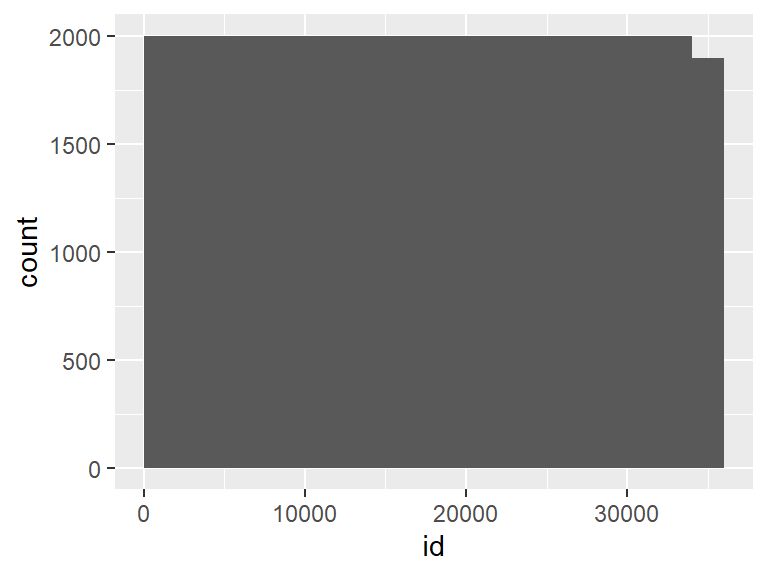

## product_A_sold_in_the_past

| Feature | Result |
| --- | --- |
| Variable type | numeric |
| Number of missing obs. | 0 (0 %) |
| Number of unique values | 234 |
| Median | -0.26 |
| 1st and 3rd quartiles | -0.26; -0.26 |
| Min. and max. | -0.26; 7.95 |

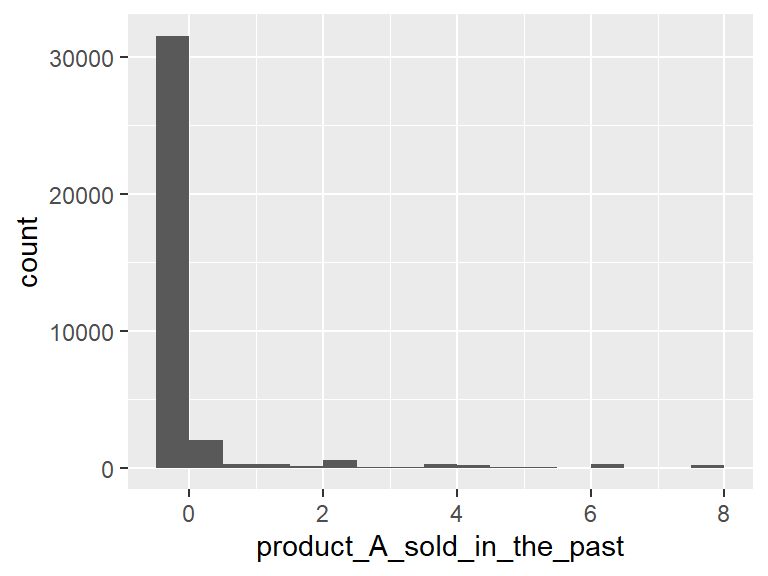

- Note that the following possible outlier values were detected: "-0.26", "-0.25", "-0.25", "-0.25", "-0.25", …, "4.07", "4.65", "5.12", "6.01", "7.95" (223 values omitted).

## product_B_sold_in_the_past

| Feature | Result |
| --- | --- |
| Variable type | numeric |
| Number of missing obs. | 0 (0 %) |
| Number of unique values | 645 |
| Median | -0.35 |
| 1st and 3rd quartiles | -0.35; -0.23 |
| Min. and max. | -0.35; 8.55 |

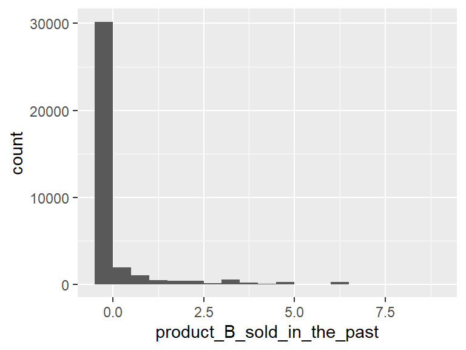

- Note that the following possible outlier values were detected: "3.52", "3.8", "3.81", "4.24", "4.64", "6.45", "6.5", "8.55".

## product_A_recommended

| Feature | Result |
| --- | --- |
| Variable type | numeric |
| Number of missing obs. | 0 (0 %) |
| Number of unique values | 131 |
| Median | -0.11 |
| 1st and 3rd quartiles | -0.11; -0.11 |
| Min. and max. | -0.11; 25.32 |

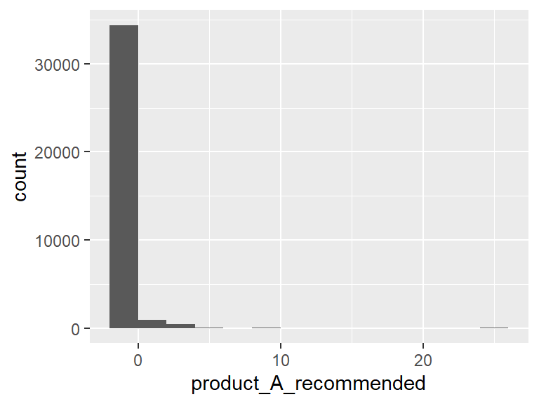

- Note that the following possible outlier values were detected: "-0.11", "-0.11", "-0.08", "-0.08", "-0.07", …, "8.15", "8.19", "9.23", "10.15", "25.32" (120 values omitted).

## product_A

| Feature | Result |
| --- | --- |
| Variable type | numeric |
| Number of missing obs. | 0 (0 %) |
| Number of unique values | 255 |
| Median | -0.09 |
| 1st and 3rd quartiles | -0.09; -0.09 |
| Min. and max. | -0.09; 18.79 |

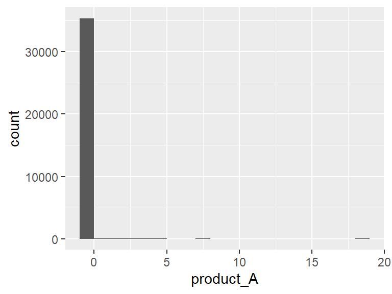

- Note that the following possible outlier values were detected: "-0.05", "-0.04", "0.03", "0.05", "0.05", …, "17.11", "17.21", "17.21", "17.21", "18.79" (244 values omitted).

## product_C

| Feature | Result |
| --- | --- |
| Variable type | numeric |
| Number of missing obs. | 0 (0 %) |
| Number of unique values | 23 |
| Median | -0.02 |
| 1st and 3rd quartiles | -0.02; -0.02 |
| Min. and max. | -0.02; 65.05 |

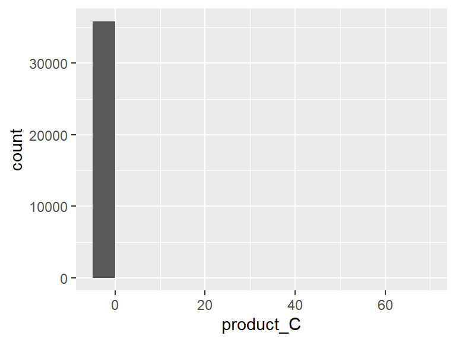

- Note that the following possible outlier values were detected: "1.94", "3.26", "4.9", "5.72", "6.51", …, "32.79", "41.34", "49.19", "52.47", "65.05" (12 values omitted).

## product_D

| Feature | Result |
| --- | --- |
| Variable type | numeric |
| Number of missing obs. | 0 (0 %) |
| Number of unique values | 102 |
| Median | -0.04 |
| 1st and 3rd quartiles | -0.04; -0.04 |
| Min. and max. | -0.04; 36.23 |

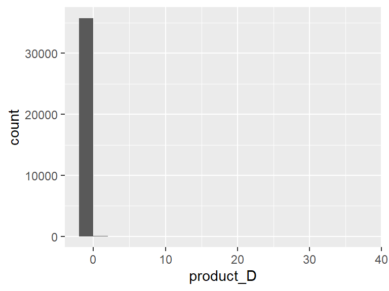

- Note that the following possible outlier values were detected: "0.01", "0.03", "0.08", "0.08", "0.1", …, "33.1", "35.55", "35.95", "36.21", "36.23" (91 values omitted).

## cust_hitrate

| Feature | Result |
| --- | --- |
| Variable type | numeric |
| Number of missing obs. | 0 (0 %) |
| Number of unique values | 4390 |
| Median | -0.22 |
| 1st and 3rd quartiles | -0.93; 0.84 |
| Min. and max. | -1.17; 1.73 |

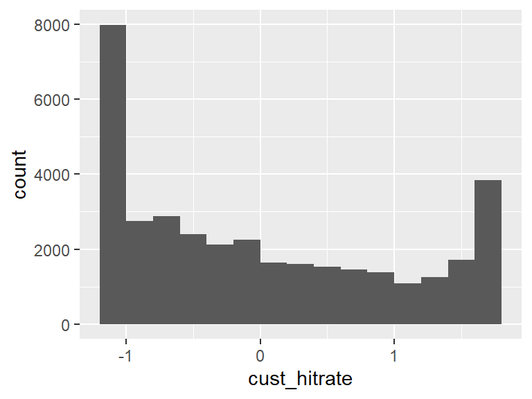

## cust_interactions

| Feature | Result |
| --- | --- |
| Variable type | numeric |
| Number of missing obs. | 0 (0 %) |
| Number of unique values | 530 |
| Median | -0.43 |
| 1st and 3rd quartiles | -0.68; 0.36 |
| Min. and max. | -0.68; 13.23 |

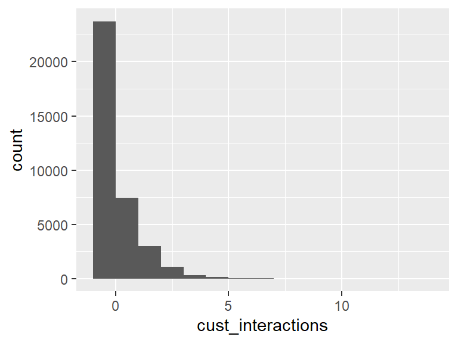

- Note that the following possible outlier values were detected: "9.73", "9.78", "10", "10.13", "10.7", "11.58", "13.23".

## cust_contracts

| Feature | Result |
| --- | --- |
| Variable type | numeric |
| Number of missing obs. | 0 (0 %) |
| Number of unique values | 28 |
| Median | -0.35 |
| 1st and 3rd quartiles | -0.35; -0.35 |
| Min. and max. | -0.35; 10.46 |

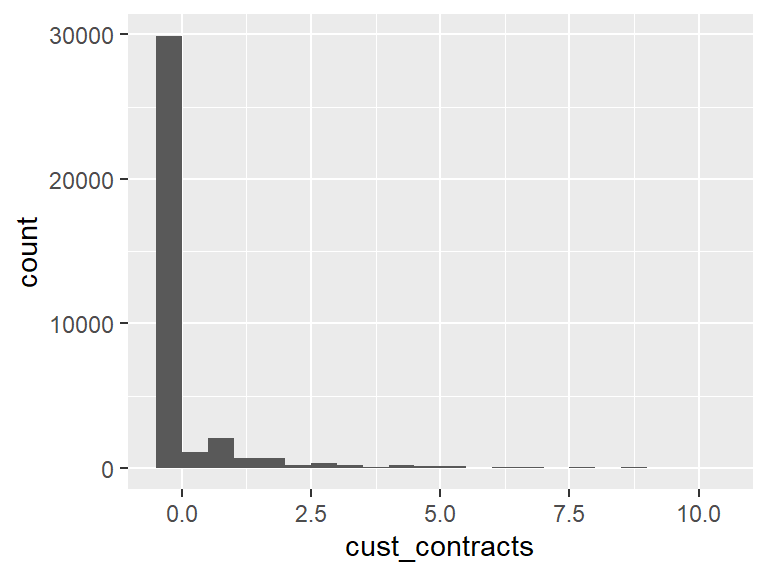

- Note that the following possible outlier values were detected: "-0.03", "0.29", "0.6", "0.92", "1.24", …, "7.6", "8.87", "9.19", "9.82", "10.46" (17 values omitted).

## opp_month

| Feature | Result |
| --- | --- |
| Variable type | numeric |
| Number of missing obs. | 0 (0 %) |
| Number of unique values | 12 |
| Median | -0.23 |
| 1st and 3rd quartiles | -0.82; 0.95 |
| Min. and max. | -1.41; 1.83 |

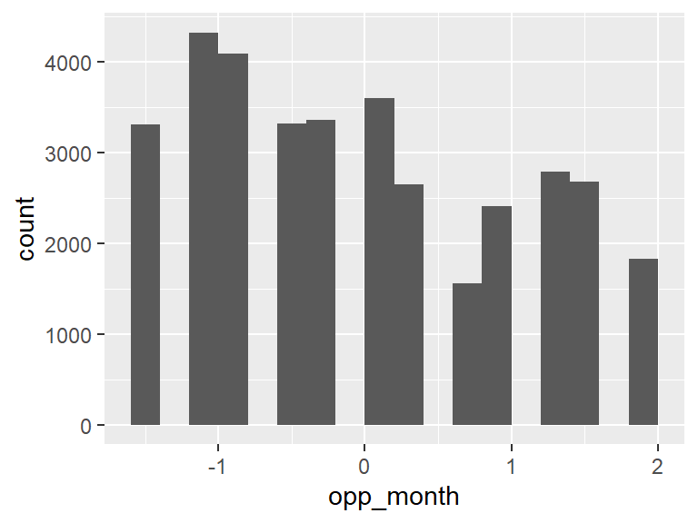

## opp_old

- Note that this variable is treated as a factor variable below, as it only takes a few unique values.

| Feature | Result |
| --- | --- |
| Variable type | numeric |
| Number of missing obs. | 0 (0 %) |
| Number of unique values | 2 |
| Mode | “-0.28185” |
| Reference category | -0.28185 |

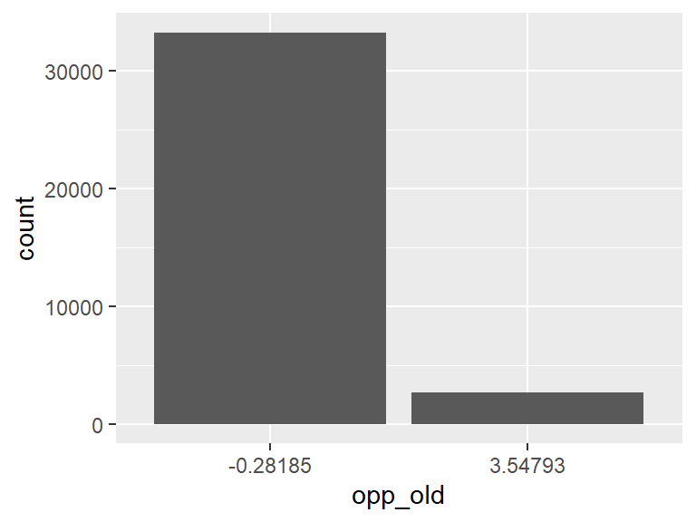

## competitor_Z

- Note that this variable is treated as a factor variable below, as it only takes a few unique values.

| Feature | Result |
| --- | --- |
| Variable type | integer |
| Number of missing obs. | 0 (0 %) |
| Number of unique values | 2 |
| Mode | “0” |
| Reference category | 0 |

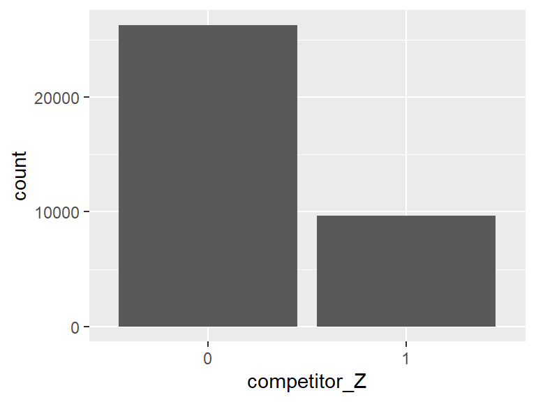

## competitor_X

- Note that this variable is treated as a factor variable below, as it only takes a few unique values.

| Feature | Result |
| --- | --- |
| Variable type | integer |
| Number of missing obs. | 0 (0 %) |
| Number of unique values | 2 |
| Mode | “0” |
| Reference category | 0 |

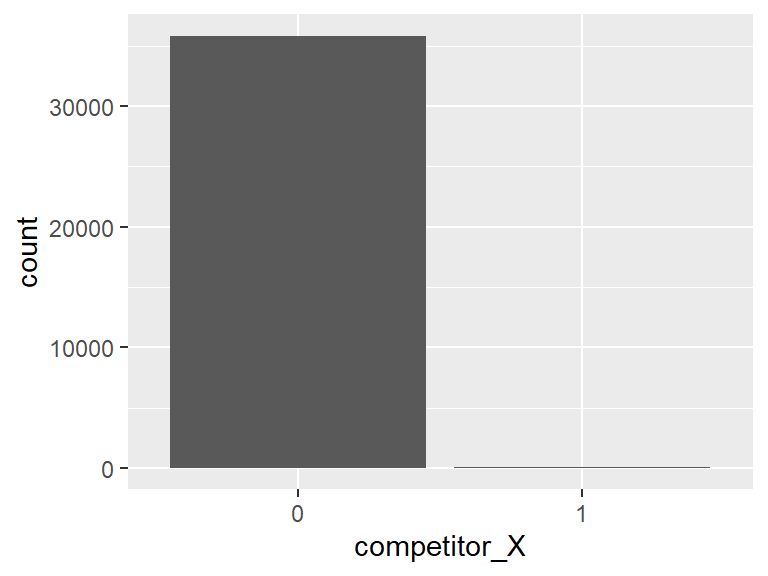

## competitor_Y

- Note that this variable is treated as a factor variable below, as it only takes a few unique values.

| Feature | Result |
| --- | --- |
| Variable type | integer |
| Number of missing obs. | 0 (0 %) |
| Number of unique values | 2 |
| Mode | “0” |
| Reference category | 0 |

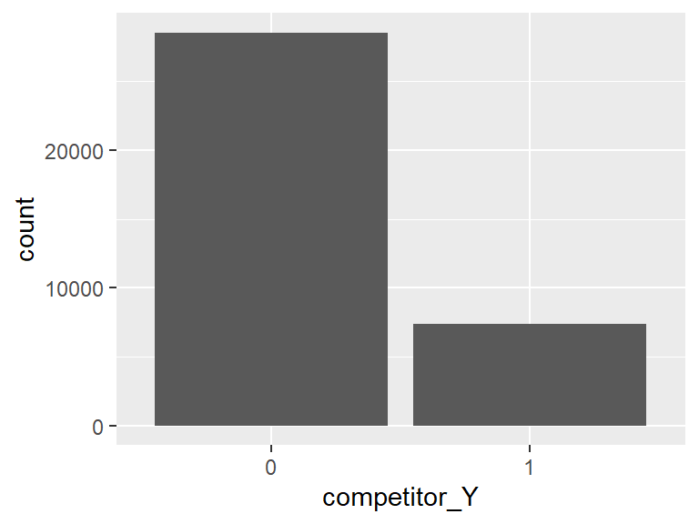

## cust_in_iberia

- Note that this variable is treated as a factor variable below, as it only takes a few unique values.

| Feature | Result |
| --- | --- |
| Variable type | integer |
| Number of missing obs. | 0 (0 %) |
| Number of unique values | 2 |
| Mode | “1” |
| Reference category | 0 |

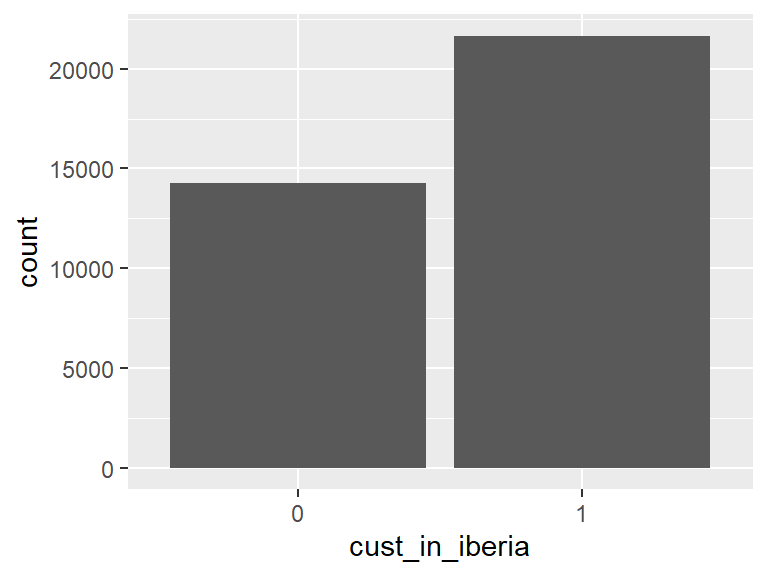

## target_variable

| Feature | Result |
| --- | --- |
| Variable type | factor |
| Number of missing obs. | 0 (0 %) |
| Number of unique values | 2 |
| Mode | “Lost” |
| Reference category | Lost |

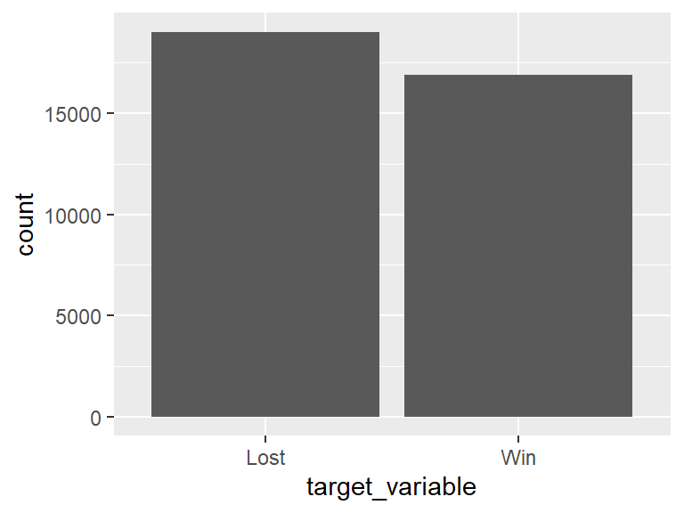

Report generation information:

- Created by: crostarup (username: `crost`).
- Report creation time: sá. nov. 15 2025 13:37:04
- Report was run from directory: `C:/Users/crost/Desktop`
- dataMaid v1.4.2 [Pkg: 2025-04-13 from standard (@1.4.2)]
- R version 4.5.1 (2025-06-13 ucrt).
- Platform: x86_64-w64-mingw32/x64(Europe/Madrid).
- Function call: `makeDataReport(data = sn_data, output = "html", replace = TRUE)`